# Predictive Models Take Home Exam

### (d)

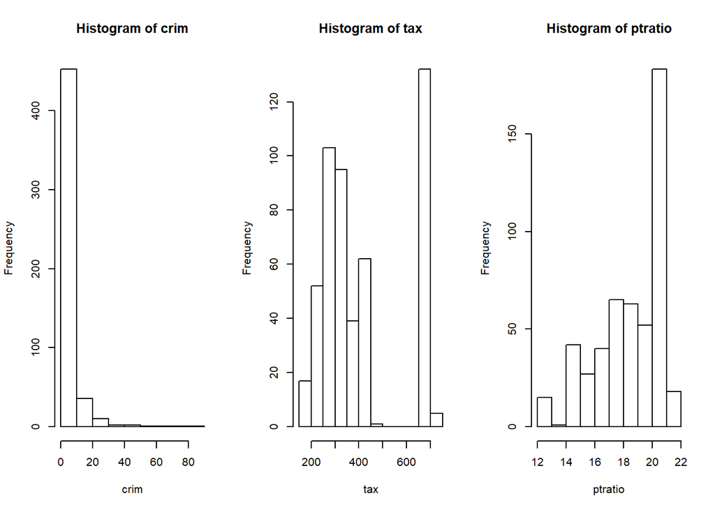

```r
par(mfrow=c(1,3))
hist(crim)
hist(tax)
hist(ptratio)
```

```r
length(crim[crim>40])
```

```
## [1] 6
```

According to the first plot, we can see most of the suburb has low crime rates. But there are 6 areas that crime rates are above 40.  
Based on the second plot, we can see that there is a big difference in tax rates. There are many low tax rates area but there are not few high tax rates areas too.  
According to the last plot, most areas have high ratio.

### (e)

```r
length(chas[chas==1])
```

```
## [1] 35
```

There are 35 suburbs bound the Charles river.

### (f)

```r
median(ptratio)
```

```
## [1] 19.05
```

The median pupil-teacher ratio is 19.05.

### (g)

```r
t(subset(Boston, medv == min(medv)))
```

```
##              399      406
## crim     38.3518  67.9208
## zn        0.0000   0.0000
## indus    18.1000  18.1000
## chas      0.0000   0.0000
## nox       0.6930   0.6930
## rm        5.4530   5.6830
## age     100.0000 100.0000
## dis       1.4896   1.4254
## rad      24.0000  24.0000
## tax     666.0000 666.0000
## ptratio  20.2000  20.2000
## black   396.9000 384.9700
## lstat    30.5900  22.9800
## medv      5.0000   5.0000
```

```r
summary(zn)
```

```
##    Min. 1st Qu.  Median    Mean 3rd Qu.    Max.
##    0.00    0.00    0.00   11.36   12.50  100.00
```

```r
summary(nox)
```

```
##    Min. 1st Qu.  Median    Mean 3rd Qu.    Max.
##  0.3850  0.4490  0.5380  0.5547  0.6240  0.8710
```

```r
summary(tax)
```

```
##    Min. 1st Qu.  Median    Mean 3rd Qu.    Max.
##   187.0   279.0   330.0   408.2   666.0   711.0
```

```r
summary(lstat)
```

```
##    Min. 1st Qu.  Median    Mean 3rd Qu.    Max.
##    1.73    6.95   11.36   12.65   16.95   37.97
```

There are two suburbs has lowest medv. They are pretty similar in other predictors too. They both have high crime rates, low zn, not bounded by river, high on nox, very old houses, high tax rates, high ptratio and high lstat.

### (h)

```r
length(rm[rm>7])
```

```
## [1] 64
```

```r
length(rm[rm>8])
```

```
## [1] 13
```

```r
t(subset(Boston,rm>8))
```

```
##                98       164       205       225       226       227
## crim      0.12083   1.51902   0.02009   0.31533   0.52693   0.38214
## zn        0.00000   0.00000  95.00000   0.00000   0.00000   0.00000
## indus     2.89000  19.58000   2.68000   6.20000   6.20000   6.20000
## chas      0.00000   1.00000   0.00000   0.00000   0.00000   0.00000
## nox       0.44500   0.60500   0.41610   0.50400   0.50400   0.50400
## rm        8.06900   8.37500   8.03400   8.26600   8.72500   8.04000
## age      76.00000  93.90000  31.90000  78.30000  83.00000  86.50000
## dis       3.49520   2.16200   5.11800   2.89440   2.89440   3.21570
## rad       2.00000   5.00000   4.00000   8.00000   8.00000   8.00000
## tax     276.00000 403.00000 224.00000 307.00000 307.00000 307.00000
## ptratio  18.00000  14.70000  14.70000  17.40000  17.40000  17.40000
## black   396.90000 388.45000 390.55000 385.05000 382.00000 387.38000
## lstat     4.21000   3.32000   2.88000   4.14000   4.63000   3.13000
## medv     38.70000  50.00000  50.00000  44.80000  50.00000  37.60000
##               233       234       254       258       263       268
## crim      0.57529   0.33147   0.36894   0.61154   0.52014   0.57834
## zn        0.00000   0.00000  22.00000  20.00000  20.00000  20.00000
## indus     6.20000   6.20000   5.86000   3.97000   3.97000   3.97000
## chas      0.00000   0.00000   0.00000   0.00000   0.00000   0.00000
## nox       0.50700   0.50700   0.43100   0.64700   0.64700   0.57500
## rm        8.33700   8.24700   8.25900   8.70400   8.39800   8.29700
## age      73.30000  70.40000   8.40000  86.90000  91.50000  67.00000
## dis       3.83840   3.65190   8.90670   1.80100   2.28850   2.42160
## rad       8.00000   8.00000   7.00000   5.00000   5.00000   5.00000
## tax     307.00000 307.00000 330.00000 264.00000 264.00000 264.00000
## ptratio  17.40000  17.40000  19.10000  13.00000  13.00000  13.00000
## black   385.91000 378.95000 396.90000 389.70000 386.86000 384.54000
## lstat     2.47000   3.95000   3.54000   5.12000   5.91000   7.44000
## medv     41.70000  48.30000  42.80000  50.00000  48.80000  50.00000
##               365
## crim      3.47428
## zn        0.00000
## indus    18.10000
## chas      1.00000
## nox       0.71800
## rm        8.78000
## age      82.90000
## dis       1.90470
## rad      24.00000
## tax     666.00000
## ptratio  20.20000
## black   354.55000
## lstat     5.29000
## medv     21.90000
```

There are 64 suburbs average more than 7 rooms per dwelling, and there are 13 suburbs average more than 8 rooms per dwelling.  
Suburbs with 8 rm tends to have low crim andlow lstat.

## Chapter 3 # 15

### (a)

```r
lm.zn = lm(crim~zn)
lm.indus = lm(crim~indus)
lm.chas = lm(crim~chas)
lm.nox = lm(crim~nox)
lm.rm = lm(crim~rm)
lm.age = lm(crim~age)
lm.dis = lm(crim~dis)
lm.rad = lm(crim~rad)
lm.tax = lm(crim~tax)
lm.ptratio = lm(crim~ptratio)
lm.black = lm(crim~black)
lm.lstat = lm(crim~lstat)
lm.medv = lm(crim~medv)
summary(lm.zn)
```

```
##
## Call:
## lm(formula = crim ~ zn)
##
## Residuals:
##    Min     1Q Median     3Q    Max
## -4.429 -4.222 -2.620  1.250 84.523
##
## Coefficients:
##             Estimate Std. Error t value Pr(>|t|)
## (Intercept)  4.45369    0.41722  10.675  < 2e-16 ***
## zn          -0.07393    0.01609  -4.594 5.51e-06 ***
## ---
## Signif. codes:  0 '***' 0.001 '**' 0.01 '*' 0.05 '.' 0.1 ' ' 1
##
## Residual standard error: 8.435 on 504 degrees of freedom
## Multiple R-squared:  0.04019,    Adjusted R-squared:  0.03828
## F-statistic:  21.1 on 1 and 504 DF,  p-value: 5.506e-06
```

```r
summary(lm.indus)
```

```
##
## Call:
## lm(formula = crim ~ indus)
##
## Residuals:
##     Min      1Q  Median      3Q     Max
## -11.972  -2.698  -0.736   0.712  81.813
##
## Coefficients:
##             Estimate Std. Error t value Pr(>|t|)
## (Intercept) -2.06374    0.66723  -3.093  0.00209 **
## indus        0.50978    0.05102   9.991  < 2e-16 ***
## ---
## Signif. codes:  0 '***' 0.001 '**' 0.01 '*' 0.05 '.' 0.1 ' ' 1
##
## Residual standard error: 7.866 on 504 degrees of freedom
## Multiple R-squared:  0.1653, Adjusted R-squared:  0.1637
## F-statistic: 99.82 on 1 and 504 DF,  p-value: < 2.2e-16
```

```r
summary(lm.chas)
```

```
##
## Call:
## lm(formula = crim ~ chas)
##
## Residuals:
##    Min     1Q Median     3Q    Max
## -3.738 -3.661 -3.435  0.018 85.232
##
## Coefficients:
##             Estimate Std. Error t value Pr(>|t|)
## (Intercept)   3.7444     0.3961   9.453   <2e-16 ***
## chas         -1.8928     1.5061  -1.257    0.209
## ---
## Signif. codes:  0 '***' 0.001 '**' 0.01 '*' 0.05 '.' 0.1 ' ' 1
##
## Residual standard error: 8.597 on 504 degrees of freedom
## Multiple R-squared:  0.003124,   Adjusted R-squared:  0.001146
## F-statistic: 1.579 on 1 and 504 DF,  p-value: 0.2094
```

```r
summary(lm.nox)
```

```
##
## Call:
## lm(formula = crim ~ nox)
##
## Residuals:
##     Min      1Q  Median      3Q     Max
## -12.371  -2.738  -0.974   0.559  81.728
##
## Coefficients:
##             Estimate Std. Error t value Pr(>|t|)
## (Intercept)  -13.720      1.699  -8.073 5.08e-15 ***
## nox           31.249      2.999  10.419  < 2e-16 ***
## ---
## Signif. codes:  0 '***' 0.001 '**' 0.01 '*' 0.05 '.' 0.1 ' ' 1
##
## Residual standard error: 7.81 on 504 degrees of freedom
## Multiple R-squared:  0.1772, Adjusted R-squared:  0.1756
## F-statistic: 108.6 on 1 and 504 DF,  p-value: < 2.2e-16
```

```r
summary(lm.rm)
```

```
##
## Call:
## lm(formula = crim ~ rm)
##
## Residuals:
##    Min     1Q Median     3Q    Max
## -6.604 -3.952 -2.654  0.989 87.197
##
## Coefficients:
##             Estimate Std. Error t value Pr(>|t|)
## (Intercept)   20.482      3.365   6.088 2.27e-09 ***
## rm            -2.684      0.532  -5.045 6.35e-07 ***
## ---
## Signif. codes:  0 '***' 0.001 '**' 0.01 '*' 0.05 '.' 0.1 ' ' 1
##
## Residual standard error: 8.401 on 504 degrees of freedom
## Multiple R-squared:  0.04807,    Adjusted R-squared:  0.04618
## F-statistic: 25.45 on 1 and 504 DF,  p-value: 6.347e-07
```

```r
summary(lm.age)
```

```
##
## Call:
## lm(formula = crim ~ age)
##
## Residuals:
##    Min     1Q Median     3Q    Max
## -6.789 -4.257 -1.230  1.527 82.849
##
## Coefficients:
##             Estimate Std. Error t value Pr(>|t|)
## (Intercept) -3.77791    0.94398  -4.002 7.22e-05 ***
## age          0.10779    0.01274   8.463 2.85e-16 ***
## ---
## Signif. codes:  0 '***' 0.001 '**' 0.01 '*' 0.05 '.' 0.1 ' ' 1
##
## Residual standard error: 8.057 on 504 degrees of freedom
## Multiple R-squared:  0.1244, Adjusted R-squared:  0.1227
## F-statistic: 71.62 on 1 and 504 DF,  p-value: 2.855e-16
```

```r
summary(lm.dis)
```

```
##
## Call:
## lm(formula = crim ~ dis)
##
## Residuals:
##    Min     1Q Median     3Q    Max
## -6.708 -4.134 -1.527  1.516 81.674
##
## Coefficients:
##             Estimate Std. Error t value Pr(>|t|)
## (Intercept)   9.4993     0.7304  13.006   <2e-16 ***
## dis          -1.5509     0.1683  -9.213   <2e-16 ***
## ---
## Signif. codes:  0 '***' 0.001 '**' 0.01 '*' 0.05 '.' 0.1 ' ' 1
##
## Residual standard error: 7.965 on 504 degrees of freedom
## Multiple R-squared:  0.1441, Adjusted R-squared:  0.1425
## F-statistic: 84.89 on 1 and 504 DF,  p-value: < 2.2e-16
```

```r
summary(lm.rad)
```

```
##
## Call:
## lm(formula = crim ~ rad)
##
## Residuals:
##     Min      1Q  Median      3Q     Max
## -10.164  -1.381  -0.141   0.660  76.433
##
## Coefficients:
##             Estimate Std. Error t value Pr(>|t|)
## (Intercept) -2.28716    0.44348  -5.157 3.61e-07 ***
## rad          0.61791    0.03433  17.998  < 2e-16 ***
## ---
## Signif. codes:  0 '***' 0.001 '**' 0.01 '*' 0.05 '.' 0.1 ' ' 1
##
## Residual standard error: 6.718 on 504 degrees of freedom
## Multiple R-squared:  0.3913, Adjusted R-squared:   0.39
## F-statistic: 323.9 on 1 and 504 DF,  p-value: < 2.2e-16
```

```r
summary(lm.tax)
```

```
##
## Call:
## lm(formula = crim ~ tax)
##
## Residuals:
##     Min      1Q  Median      3Q     Max
## -12.513  -2.738  -0.194   1.065  77.696
##
## Coefficients:
##              Estimate Std. Error t value Pr(>|t|)
## (Intercept) -8.528369   0.815809  -10.45   <2e-16 ***
## tax          0.029742   0.001847   16.10   <2e-16 ***
## ---
## Signif. codes:  0 '***' 0.001 '**' 0.01 '*' 0.05 '.' 0.1 ' ' 1
##
## Residual standard error: 6.997 on 504 degrees of freedom
## Multiple R-squared:  0.3396, Adjusted R-squared:  0.3383
## F-statistic: 259.2 on 1 and 504 DF,  p-value: < 2.2e-16
```

```r
summary(lm.ptratio)
```

```
##
## Call:
## lm(formula = crim ~ ptratio)
##
## Residuals:
##    Min     1Q Median     3Q    Max
## -7.654 -3.985 -1.912  1.825 83.353
##
## Coefficients:
##             Estimate Std. Error t value Pr(>|t|)
## (Intercept) -17.6469     3.1473  -5.607 3.40e-08 ***
## ptratio       1.1520     0.1694   6.801 2.94e-11 ***
## ---
## Signif. codes:  0 '***' 0.001 '**' 0.01 '*' 0.05 '.' 0.1 ' ' 1
##
## Residual standard error: 8.24 on 504 degrees of freedom
## Multiple R-squared:  0.08407,    Adjusted R-squared:  0.08225
## F-statistic: 46.26 on 1 and 504 DF,  p-value: 2.943e-11
```

```r
summary(lm.black)
```

```
##
## Call:
## lm(formula = crim ~ black)
##
## Residuals:
##     Min      1Q  Median      3Q     Max
## -13.756  -2.299  -2.095  -1.296  86.822
##
## Coefficients:
##              Estimate Std. Error t value Pr(>|t|)
## (Intercept) 16.553529   1.425903  11.609   <2e-16 ***
## black       -0.036280   0.003873  -9.367   <2e-16 ***
## ---
## Signif. codes:  0 '***' 0.001 '**' 0.01 '*' 0.05 '.' 0.1 ' ' 1
##
## Residual standard error: 7.946 on 504 degrees of freedom
## Multiple R-squared:  0.1483, Adjusted R-squared:  0.1466
## F-statistic: 87.74 on 1 and 504 DF,  p-value: < 2.2e-16
```

```r
summary(lm.lstat)
```

```
##
## Call:
## lm(formula = crim ~ lstat)
##
## Residuals:
##     Min      1Q  Median      3Q     Max
## -13.925  -2.822  -0.664   1.079  82.862
##
## Coefficients:
##             Estimate Std. Error t value Pr(>|t|)
## (Intercept) -3.33054    0.69376  -4.801 2.09e-06 ***
## lstat        0.54880    0.04776  11.491  < 2e-16 ***
## ---
## Signif. codes:  0 '***' 0.001 '**' 0.01 '*' 0.05 '.' 0.1 ' ' 1
##
## Residual standard error: 7.664 on 504 degrees of freedom
## Multiple R-squared:  0.2076, Adjusted R-squared:  0.206
## F-statistic:   132 on 1 and 504 DF,  p-value: < 2.2e-16
```

```r
summary(lm.medv)
```

```
##
## Call:
## lm(formula = crim ~ medv)
##
## Residuals:
##    Min     1Q Median     3Q    Max
## -9.071 -4.022 -2.343  1.298 80.957
##
## Coefficients:
##             Estimate Std. Error t value Pr(>|t|)
## (Intercept) 11.79654    0.93419   12.63   <2e-16 ***
## medv        -0.36316    0.03839   -9.46   <2e-16 ***
## ---
## Signif. codes:  0 '***' 0.001 '**' 0.01 '*' 0.05 '.' 0.1 ' ' 1
##
## Residual standard error: 7.934 on 504 degrees of freedom
## Multiple R-squared:  0.1508, Adjusted R-squared:  0.1491
## F-statistic: 89.49 on 1 and 504 DF,  p-value: < 2.2e-16
```

It turns out that almost every predictors have statistically significant association with crim, except for chas.

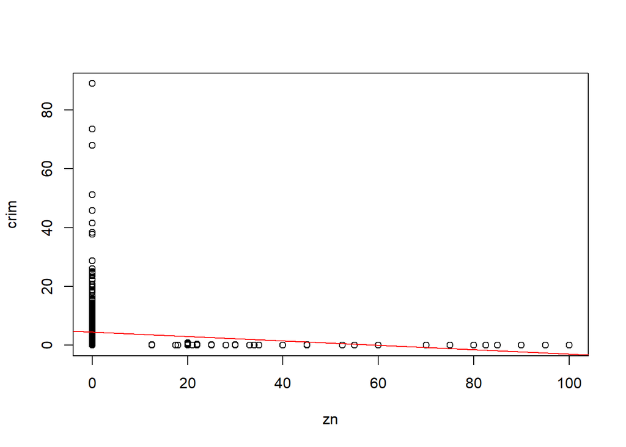

```r
plot(zn,crim)
abline(lm.zn,col='red')
```

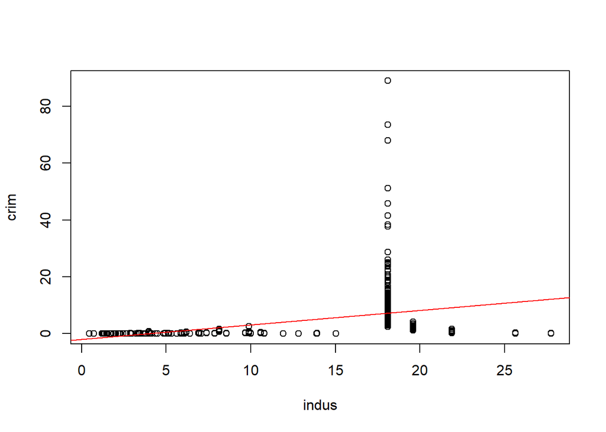

```r
plot(indus,crim)
abline(lm.indus,col='red')
```

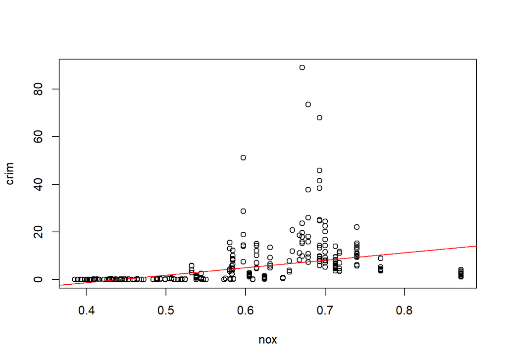

```r
plot(nox,crim)
abline(lm.nox,col='red')
```

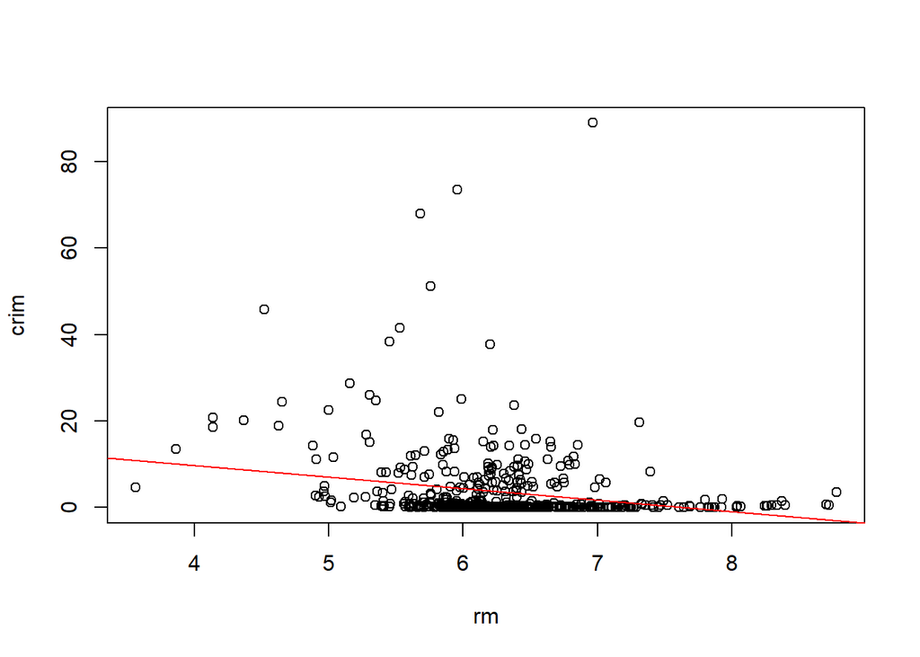

```r
plot(rm,crim)
abline(lm.rm,col='red')
```

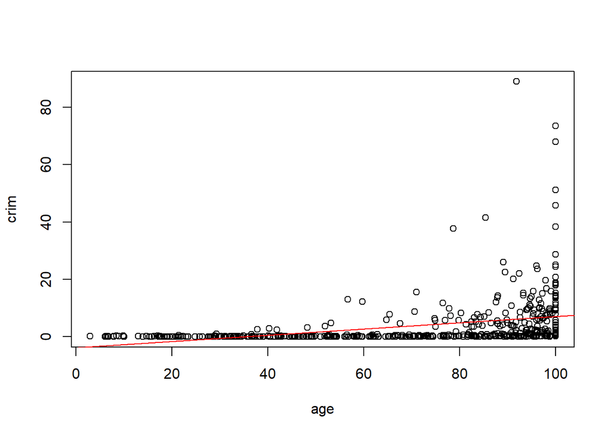

```r
plot(age,crim)
abline(lm.age,col='red')
```

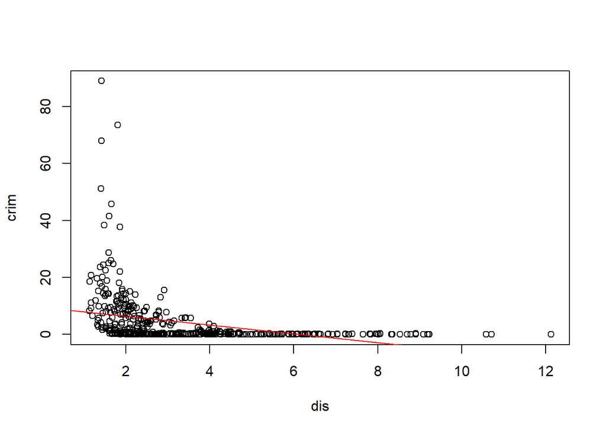

```r
plot(dis,crim)
abline(lm.dis,col='red')
```

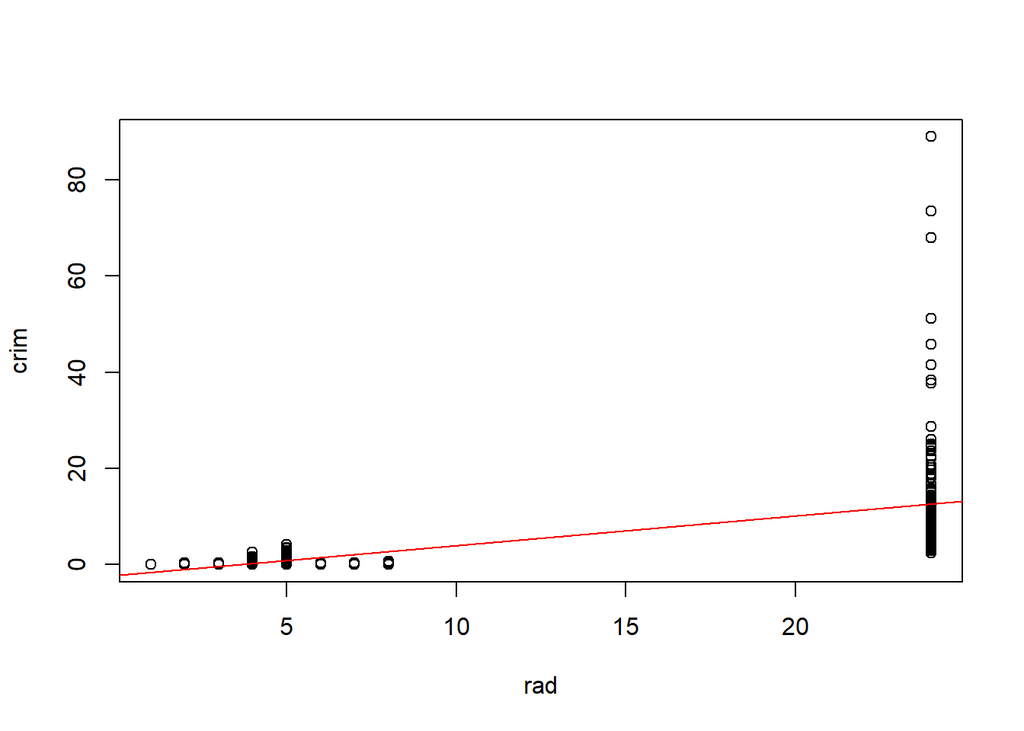

```r
plot(rad,crim)
abline(lm.rad,col='red')
```

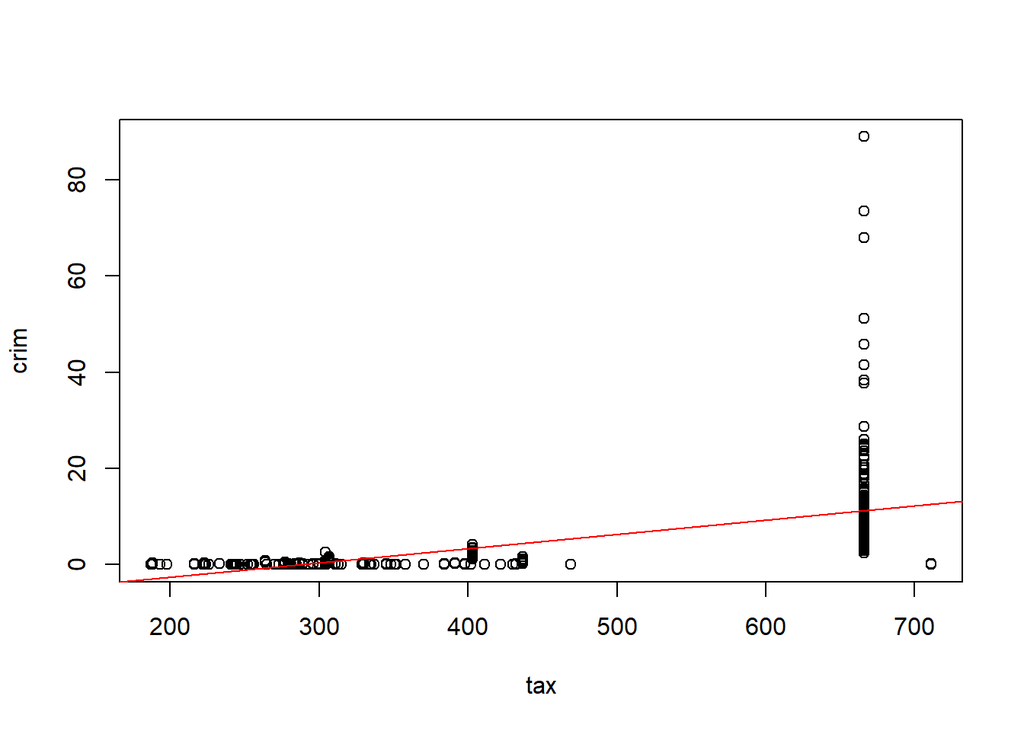

```r
plot(tax,crim)
abline(lm.tax,col='red')
```

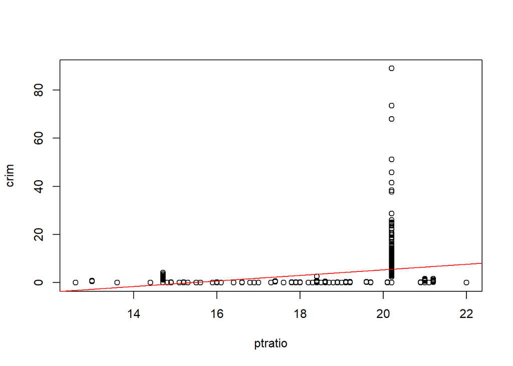

```r
plot(ptratio,crim)
abline(lm.ptratio,col='red')
```

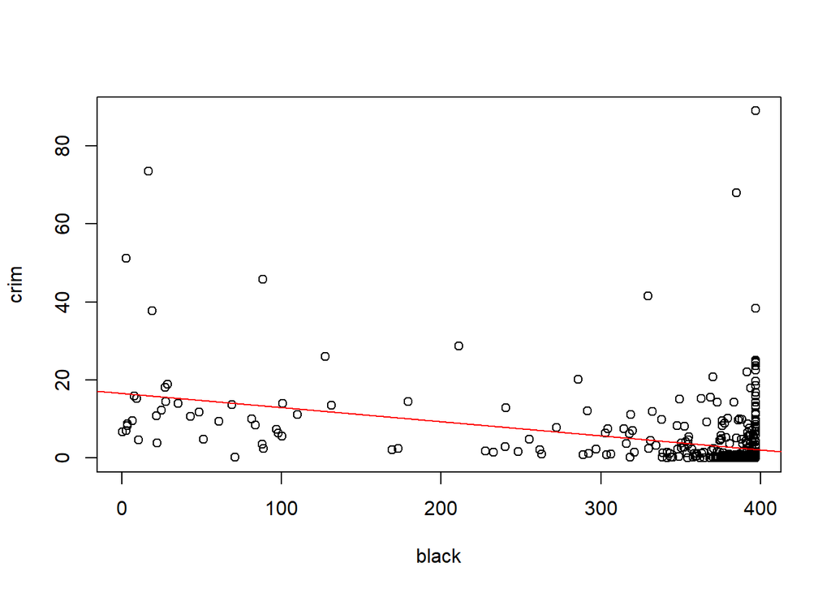

```r
plot(black,crim)
abline(lm.black,col='red')
```

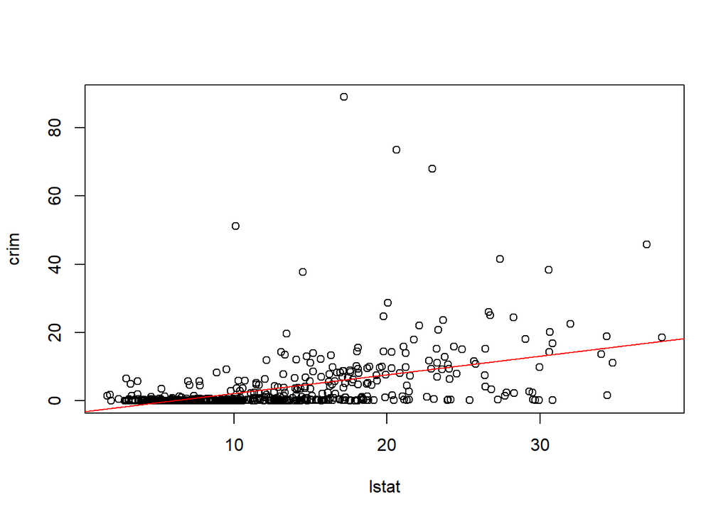

```r
plot(lstat,crim)
abline(lm.lstat,col='red')
```

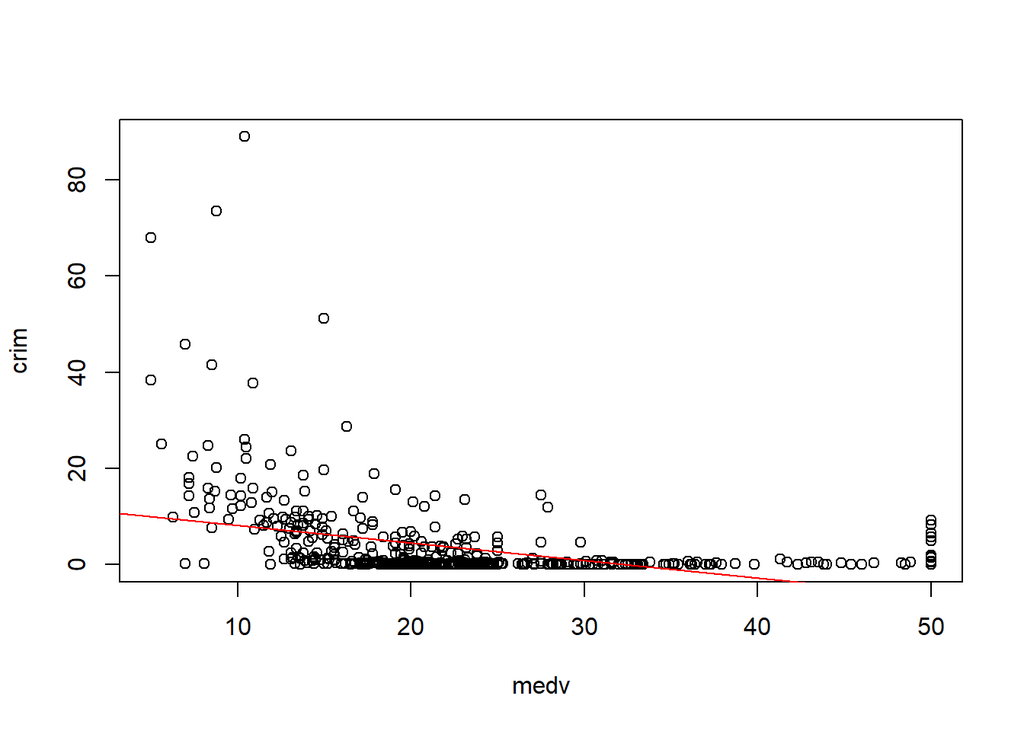

```r
plot(medv,crim)
abline(lm.medv,col='red')
```

As we can see, the red line(linear regression function) often represent the trend.

### (b)

```r
lm.all = lm(crim~. , data = Boston)
summary(lm.all)
```

```
##
## Call:
## lm(formula = crim ~ ., data = Boston)
##
## Residuals:
##    Min     1Q Median     3Q    Max
## -9.924 -2.120 -0.353  1.019 75.051
##
## Coefficients:
##               Estimate Std. Error t value Pr(>|t|)
## (Intercept)  17.033228   7.234903   2.354 0.018949 *
## zn            0.044855   0.018734   2.394 0.017025 *
## indus        -0.063855   0.083407  -0.766 0.444294
## chas         -0.749134   1.180147  -0.635 0.525867
## nox         -10.313535   5.275536  -1.955 0.051152 .
## rm            0.430131   0.612830   0.702 0.483089
## age           0.001452   0.017925   0.081 0.935488
## dis          -0.987176   0.281817  -3.503 0.000502 ***
## rad           0.588209   0.088049   6.680 6.46e-11 ***
## tax          -0.003780   0.005156  -0.733 0.463793
## ptratio      -0.271081   0.186450  -1.454 0.146611
## black        -0.007538   0.003673  -2.052 0.040702 *
## lstat         0.126211   0.075725   1.667 0.096208 .
## medv         -0.198887   0.060516  -3.287 0.001087 **
## ---
## Signif. codes:  0 '***' 0.001 '**' 0.01 '*' 0.05 '.' 0.1 ' ' 1
##
## Residual standard error: 6.439 on 492 degrees of freedom
## Multiple R-squared:  0.454,  Adjusted R-squared:  0.4396
## F-statistic: 31.47 on 13 and 492 DF,  p-value: < 2.2e-16
```

Under 95% confidence level, we can reject zn, dis, rad, black and medv’s null hypothesis.

### (c)

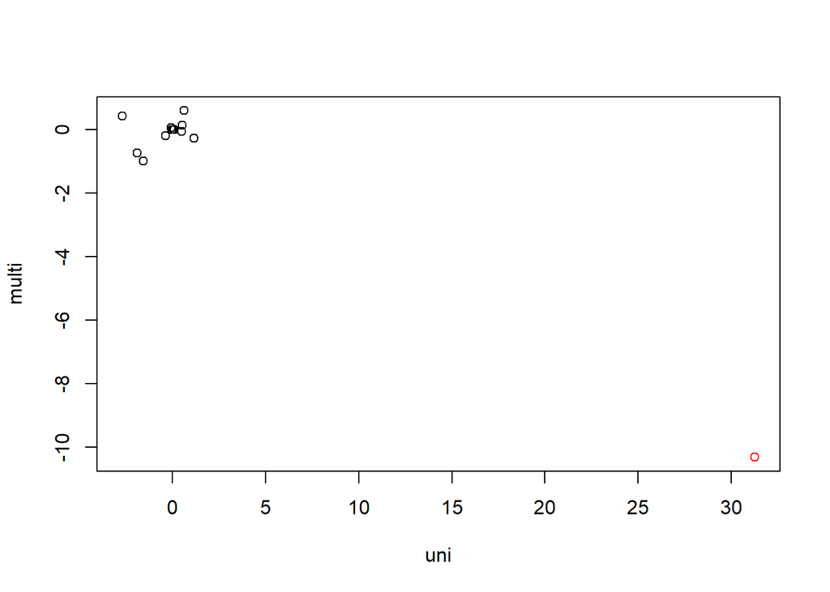

```r
uni = c(coefficients(lm.zn)[2],
      coefficients(lm.indus)[2],
      coefficients(lm.chas)[2],
      coefficients(lm.nox)[2],
      coefficients(lm.rm)[2],
      coefficients(lm.age)[2],
      coefficients(lm.dis)[2],
      coefficients(lm.rad)[2],
      coefficients(lm.tax)[2],
      coefficients(lm.ptratio)[2],
      coefficients(lm.black)[2],
      coefficients(lm.lstat)[2],
      coefficients(lm.medv)[2])
multi = coefficients(lm.all)[2:14]
plot(uni, multi)
points(uni[4], multi[4],col='red')
```

Coefficient for nox is 31 in simple regression but in multivariate regression it is -10.

### (d)

```r
lm.zn3 = lm(crim~poly(zn,3))
lm.indus3 = lm(crim~poly(indus,3))
lm.nox3 = lm(crim~poly(nox,3))
lm.rm3 = lm(crim~poly(rm,3))
lm.age3 = lm(crim~poly(age,3))
lm.dis3 = lm(crim~poly(dis,3))
lm.rad3 = lm(crim~poly(rad,3))
lm.tax3 = lm(crim~poly(tax,3))
lm.ptratio3 = lm(crim~poly(ptratio,3))
lm.black3 = lm(crim~poly(black,3))
lm.lstat3 = lm(crim~poly(lstat,3))
lm.medv3 = lm(crim~poly(medv,3))
summary(lm.zn3)
```

```
##
## Call:
## lm(formula = crim ~ poly(zn, 3))
##
## Residuals:
##    Min     1Q Median     3Q    Max
## -4.821 -4.614 -1.294  0.473 84.130
##
## Coefficients:
##              Estimate Std. Error t value Pr(>|t|)
## (Intercept)    3.6135     0.3722   9.709  < 2e-16 ***
## poly(zn, 3)1 -38.7498     8.3722  -4.628  4.7e-06 ***
## poly(zn, 3)2  23.9398     8.3722   2.859  0.00442 **
## poly(zn, 3)3 -10.0719     8.3722  -1.203  0.22954
## ---
## Signif. codes:  0 '***' 0.001 '**' 0.01 '*' 0.05 '.' 0.1 ' ' 1
##
## Residual standard error: 8.372 on 502 degrees of freedom
## Multiple R-squared:  0.05824,    Adjusted R-squared:  0.05261
## F-statistic: 10.35 on 3 and 502 DF,  p-value: 1.281e-06
```

```r
summary(lm.indus3)
```

```
##
## Call:
## lm(formula = crim ~ poly(indus, 3))
##
## Residuals:
##    Min     1Q Median     3Q    Max
## -8.278 -2.514  0.054  0.764 79.713
##
## Coefficients:
##                 Estimate Std. Error t value Pr(>|t|)
## (Intercept)        3.614      0.330  10.950  < 2e-16 ***
## poly(indus, 3)1   78.591      7.423  10.587  < 2e-16 ***
## poly(indus, 3)2  -24.395      7.423  -3.286  0.00109 **
## poly(indus, 3)3  -54.130      7.423  -7.292  1.2e-12 ***
## ---
## Signif. codes:  0 '***' 0.001 '**' 0.01 '*' 0.05 '.' 0.1 ' ' 1
##
## Residual standard error: 7.423 on 502 degrees of freedom
## Multiple R-squared:  0.2597, Adjusted R-squared:  0.2552
## F-statistic: 58.69 on 3 and 502 DF,  p-value: < 2.2e-16
```

```r
summary(lm.nox3)
```

```
##
## Call:
## lm(formula = crim ~ poly(nox, 3))
##
## Residuals:
##    Min     1Q Median     3Q    Max
## -9.110 -2.068 -0.255  0.739 78.302
##
## Coefficients:
##               Estimate Std. Error t value Pr(>|t|)
## (Intercept)     3.6135     0.3216  11.237  < 2e-16 ***
## poly(nox, 3)1  81.3720     7.2336  11.249  < 2e-16 ***
## poly(nox, 3)2 -28.8286     7.2336  -3.985 7.74e-05 ***
## poly(nox, 3)3 -60.3619     7.2336  -8.345 6.96e-16 ***
## ---
## Signif. codes:  0 '***' 0.001 '**' 0.01 '*' 0.05 '.' 0.1 ' ' 1
##
## Residual standard error: 7.234 on 502 degrees of freedom
## Multiple R-squared:  0.297,  Adjusted R-squared:  0.2928
## F-statistic: 70.69 on 3 and 502 DF,  p-value: < 2.2e-16
```

```r
summary(lm.rm3)
```

```
##
## Call:
## lm(formula = crim ~ poly(rm, 3))
##
## Residuals:
##     Min      1Q  Median      3Q     Max
## -18.485  -3.468  -2.221  -0.015  87.219
##
## Coefficients:
##              Estimate Std. Error t value Pr(>|t|)
## (Intercept)    3.6135     0.3703   9.758  < 2e-16 ***
## poly(rm, 3)1 -42.3794     8.3297  -5.088 5.13e-07 ***
## poly(rm, 3)2  26.5768     8.3297   3.191  0.00151 **
## poly(rm, 3)3  -5.5103     8.3297  -0.662  0.50858
## ---
## Signif. codes:  0 '***' 0.001 '**' 0.01 '*' 0.05 '.' 0.1 ' ' 1
##
## Residual standard error: 8.33 on 502 degrees of freedom
## Multiple R-squared:  0.06779,    Adjusted R-squared:  0.06222
## F-statistic: 12.17 on 3 and 502 DF,  p-value: 1.067e-07
```

```r
summary(lm.age3)
```

```
##
## Call:
## lm(formula = crim ~ poly(age, 3))
##
## Residuals:
##    Min     1Q Median     3Q    Max
## -9.762 -2.673 -0.516  0.019 82.842
##
## Coefficients:
##               Estimate Std. Error t value Pr(>|t|)
## (Intercept)     3.6135     0.3485  10.368  < 2e-16 ***
## poly(age, 3)1  68.1820     7.8397   8.697  < 2e-16 ***
## poly(age, 3)2  37.4845     7.8397   4.781 2.29e-06 ***
## poly(age, 3)3  21.3532     7.8397   2.724  0.00668 **
## ---
## Signif. codes:  0 '***' 0.001 '**' 0.01 '*' 0.05 '.' 0.1 ' ' 1
##
## Residual standard error: 7.84 on 502 degrees of freedom
## Multiple R-squared:  0.1742, Adjusted R-squared:  0.1693
## F-statistic: 35.31 on 3 and 502 DF,  p-value: < 2.2e-16
```

```r
summary(lm.dis3)
```

```
##
## Call:
## lm(formula = crim ~ poly(dis, 3))
##
## Residuals:
##     Min      1Q  Median      3Q     Max
## -10.757  -2.588   0.031   1.267  76.378
##
## Coefficients:
##               Estimate Std. Error t value Pr(>|t|)
## (Intercept)     3.6135     0.3259  11.087  < 2e-16 ***
## poly(dis, 3)1 -73.3886     7.3315 -10.010  < 2e-16 ***
## poly(dis, 3)2  56.3730     7.3315   7.689 7.87e-14 ***
## poly(dis, 3)3 -42.6219     7.3315  -5.814 1.09e-08 ***
## ---
## Signif. codes:  0 '***' 0.001 '**' 0.01 '*' 0.05 '.' 0.1 ' ' 1
##
## Residual standard error: 7.331 on 502 degrees of freedom
## Multiple R-squared:  0.2778, Adjusted R-squared:  0.2735
## F-statistic: 64.37 on 3 and 502 DF,  p-value: < 2.2e-16
```

```r
summary(lm.rad3)
```

```
##
## Call:
## lm(formula = crim ~ poly(rad, 3))
##
## Residuals:
##     Min      1Q  Median      3Q     Max
## -10.381  -0.412  -0.269   0.179  76.217
##
## Coefficients:
##               Estimate Std. Error t value Pr(>|t|)
## (Intercept)     3.6135     0.2971  12.164  < 2e-16 ***
## poly(rad, 3)1 120.9074     6.6824  18.093  < 2e-16 ***
## poly(rad, 3)2  17.4923     6.6824   2.618  0.00912 **
## poly(rad, 3)3   4.6985     6.6824   0.703  0.48231
## ---
## Signif. codes:  0 '***' 0.001 '**' 0.01 '*' 0.05 '.' 0.1 ' ' 1
##
## Residual standard error: 6.682 on 502 degrees of freedom
## Multiple R-squared:    0.4,  Adjusted R-squared:  0.3965
## F-statistic: 111.6 on 3 and 502 DF,  p-value: < 2.2e-16
```

```r
summary(lm.tax3)
```

```
##
## Call:
## lm(formula = crim ~ poly(tax, 3))
##
## Residuals:
##     Min      1Q  Median      3Q     Max
## -13.273  -1.389   0.046   0.536  76.950
##
## Coefficients:
##               Estimate Std. Error t value Pr(>|t|)
## (Intercept)     3.6135     0.3047  11.860  < 2e-16 ***
## poly(tax, 3)1 112.6458     6.8537  16.436  < 2e-16 ***
## poly(tax, 3)2  32.0873     6.8537   4.682 3.67e-06 ***
## poly(tax, 3)3  -7.9968     6.8537  -1.167    0.244
## ---
## Signif. codes:  0 '***' 0.001 '**' 0.01 '*' 0.05 '.' 0.1 ' ' 1
##
## Residual standard error: 6.854 on 502 degrees of freedom
## Multiple R-squared:  0.3689, Adjusted R-squared:  0.3651
## F-statistic:  97.8 on 3 and 502 DF,  p-value: < 2.2e-16
```

```r
summary(lm.ptratio3)
```

```
##
## Call:
## lm(formula = crim ~ poly(ptratio, 3))
##
## Residuals:
##    Min     1Q Median     3Q    Max
## -6.833 -4.146 -1.655  1.408 82.697
##
## Coefficients:
##                   Estimate Std. Error t value Pr(>|t|)
## (Intercept)          3.614      0.361  10.008  < 2e-16 ***
## poly(ptratio, 3)1   56.045      8.122   6.901 1.57e-11 ***
## poly(ptratio, 3)2   24.775      8.122   3.050  0.00241 **
## poly(ptratio, 3)3  -22.280      8.122  -2.743  0.00630 **
## ---
## Signif. codes:  0 '***' 0.001 '**' 0.01 '*' 0.05 '.' 0.1 ' ' 1
##
## Residual standard error: 8.122 on 502 degrees of freedom
## Multiple R-squared:  0.1138, Adjusted R-squared:  0.1085
## F-statistic: 21.48 on 3 and 502 DF,  p-value: 4.171e-13
```

```r
summary(lm.black3)
```

```
##
## Call:
## lm(formula = crim ~ poly(black, 3))
##
## Residuals:
##     Min      1Q  Median      3Q     Max
## -13.096  -2.343  -2.128  -1.439  86.790
##
## Coefficients:
##                 Estimate Std. Error t value Pr(>|t|)
## (Intercept)       3.6135     0.3536  10.218   <2e-16 ***
## poly(black, 3)1 -74.4312     7.9546  -9.357   <2e-16 ***
## poly(black, 3)2   5.9264     7.9546   0.745    0.457
## poly(black, 3)3  -4.8346     7.9546  -0.608    0.544
## ---
## Signif. codes:  0 '***' 0.001 '**' 0.01 '*' 0.05 '.' 0.1 ' ' 1
##
## Residual standard error: 7.955 on 502 degrees of freedom
## Multiple R-squared:  0.1498, Adjusted R-squared:  0.1448
## F-statistic: 29.49 on 3 and 502 DF,  p-value: < 2.2e-16
```

```r
summary(lm.lstat3)
```

```
##
## Call:
## lm(formula = crim ~ poly(lstat, 3))
##
## Residuals:
##     Min      1Q  Median      3Q     Max
## -15.234  -2.151  -0.486   0.066  83.353
##
## Coefficients:
##                 Estimate Std. Error t value Pr(>|t|)
## (Intercept)       3.6135     0.3392  10.654   <2e-16 ***
## poly(lstat, 3)1  88.0697     7.6294  11.543   <2e-16 ***
## poly(lstat, 3)2  15.8882     7.6294   2.082   0.0378 *
## poly(lstat, 3)3 -11.5740     7.6294  -1.517   0.1299
## ---
## Signif. codes:  0 '***' 0.001 '**' 0.01 '*' 0.05 '.' 0.1 ' ' 1
##
## Residual standard error: 7.629 on 502 degrees of freedom
## Multiple R-squared:  0.2179, Adjusted R-squared:  0.2133
## F-statistic: 46.63 on 3 and 502 DF,  p-value: < 2.2e-16
```

```r
summary(lm.medv3)
```

```
##
## Call:
## lm(formula = crim ~ poly(medv, 3))
##
## Residuals:
##     Min      1Q  Median      3Q     Max
## -24.427  -1.976  -0.437   0.439  73.655
##
## Coefficients:
##                Estimate Std. Error t value Pr(>|t|)
## (Intercept)       3.614      0.292  12.374  < 2e-16 ***
## poly(medv, 3)1  -75.058      6.569 -11.426  < 2e-16 ***
## poly(medv, 3)2   88.086      6.569  13.409  < 2e-16 ***
## poly(medv, 3)3  -48.033      6.569  -7.312 1.05e-12 ***
## ---
## Signif. codes:  0 '***' 0.001 '**' 0.01 '*' 0.05 '.' 0.1 ' ' 1
##
## Residual standard error: 6.569 on 502 degrees of freedom
## Multiple R-squared:  0.4202, Adjusted R-squared:  0.4167
## F-statistic: 121.3 on 3 and 502 DF,  p-value: < 2.2e-16
```

```r
detach(Boston)
```

As we can see, indus, nox, age, dis, ptratio and medv all have 1, 2 and 3 degree polynomial relation with crim. zn, rm, rad, tax and lstat have 1 and 2 degree polynomail relation with crim, but black only have 1 degree polynomial realtion with crim.

## Chapter 6 # 9

### (a)

```r
rm(list=ls())

library(ISLR)
library(caret)
set.seed(99)
train <- createDataPartition(y = College$Apps, p=0.8,list = F)
College_train = College[train,]
College_test = College[-train,]
```

### (b)

```r
lm.all = lm(Apps~., data = College_train)
lm.pred = predict(lm.all, College_test)
err_lm = mean((College_test$Apps - lm.pred)^2)
err_lm
```

```
## [1] 1386567
```

The test error is 1386567.

### (c)

```r
library(glmnet)
set.seed(99)
train_xmat <- model.matrix(Apps~., data=College_train)[,-1]
test_xmat <- model.matrix(Apps~., data=College_test)[,-1]
ridge.fit <- cv.glmnet(train_xmat, College_train$Apps, alpha = 0)
best_lambda_ridge <- ridge.fit$lambda.min
ridge.pred <- predict(ridge.fit, s=best_lambda_ridge, newx= test_xmat)
err_ridge = mean((College_test$Apps - ridge.pred)^2)
err_ridge
```

```
## [1] 1361483
```

The test error is 1361483. Ridge regression’s test error is lower than OLS.

### (d)

```r
set.seed(99)

lasso.fit <- cv.glmnet(train_xmat, College_train$Apps, alpha = 1)
best_lambda_lasso <- lasso.fit$lambda.min
lasso.pred <- predict(lasso.fit, s=best_lambda_lasso, newx= test_xmat)
err_lasso = mean((College_test$Apps - lasso.pred)^2)
err_lasso
```

```
## [1] 1340749
```

```r
non_zero_pred <- colnames(train_xmat)[which(coef(lasso.fit,s="lambda.min")!=0)]
length(non_zero_pred)-1  # minus intercept
```

```
## [1] 16
```

Lasso regression’s test error is 1340749, which is lower than ridge regression. There are 16 non-zero coefficient estimates.

### (e)

```r
library(pls)
set.seed(99)
pcr.fit <- pcr(Apps~., data = College_train, scale=T,validation="CV" )
pcr.pred <- predict(pcr.fit, College_test,ncomp = pcr.fit$ncomp)

err_pcr = mean((College_test$Apps - pcr.pred)^2)
err_pcr
```

```
## [1] 1386567
```

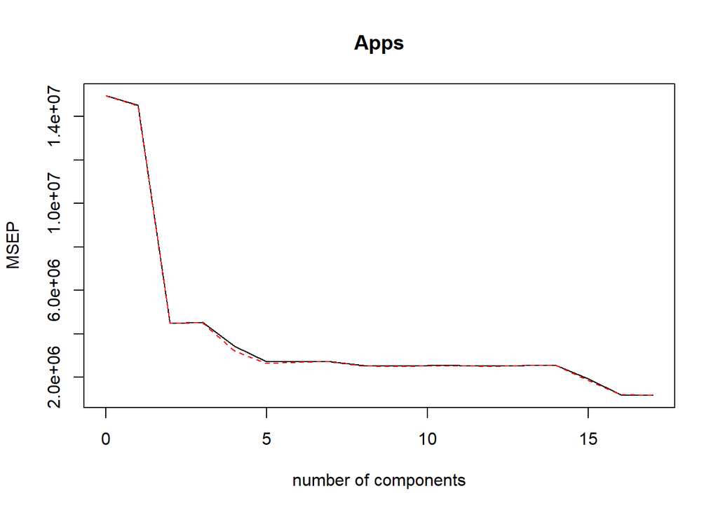

```r
validationplot(pcr.fit, val.type="MSEP")
```

```r
pcr.fit$ncomp
```

```
## [1] 17
```

PCR’s test error is 1386567. M is 17.

### (f)

```r
set.seed(99)
pls.fit <- plsr(Apps~., data = College_train, scale=T,validation="CV" )
pls.pred <- predict(pls.fit, College_test,ncomp = pls.fit$ncomp)

err_pls = mean((College_test$Apps - pls.pred)^2)
err_pls
```

```
## [1] 1386567
```

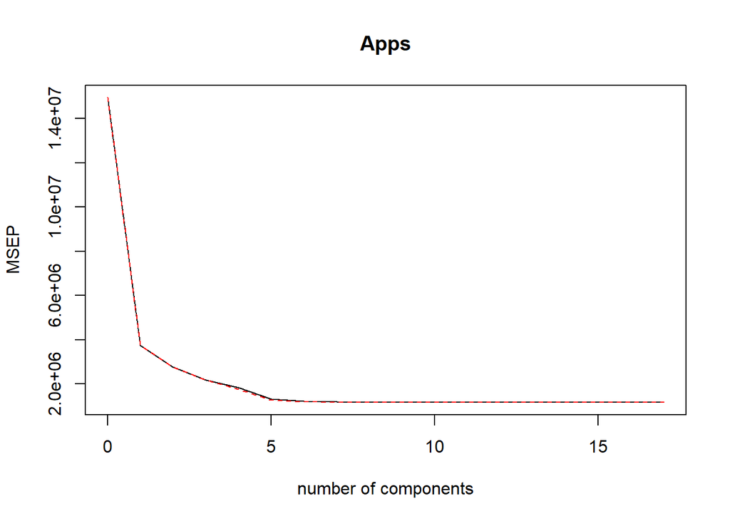

```r
validationplot(pls.fit, val.type="MSEP")
```

```r
pls.fit$ncomp
```

```
## [1] 17
```

PLS’s test error is 1386567, and M is 17.

### (g)

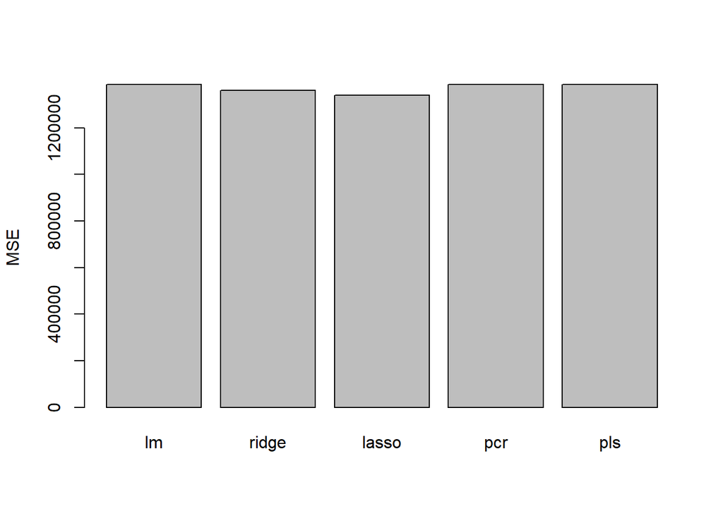

```r
all_error = c(err_lm,err_ridge,err_lasso,err_pcr,err_pls)
names(all_error) = c("lm","ridge","lasso","pcr","pls")
barplot(all_error,ylab = "MSE")
```

Although we can see that lasso regression’s test error is the smallest, it does not improve from OLS model.

## Chapter 6 # 11

### (a)

#### Best Subset

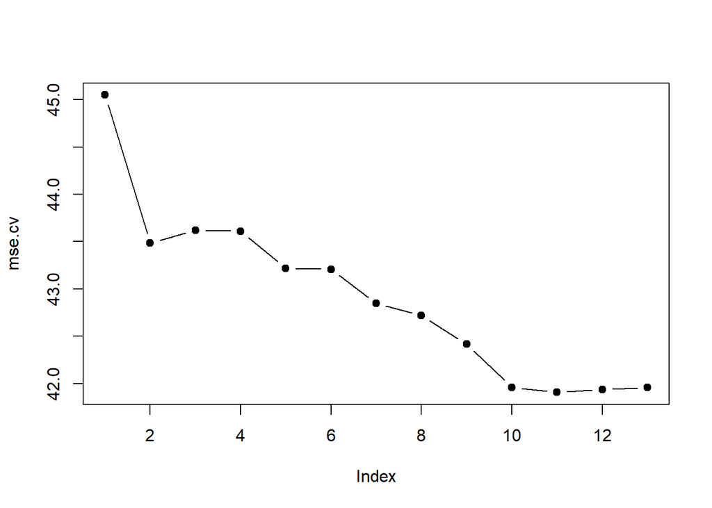

```r
rm(list=ls())

library(leaps)
set.seed(99)

#########################################################
#From internet: make predict function can be applied on #regsubsets object
predict.regsubsets <- function(object, newdata, id, ...){
  form <- as.formula(object$call[[2]])
  mat <- model.matrix(form, newdata)
  coefi <- coef(object, id=id)
  xvars <- names(coefi)
  mat[,xvars]%*%coefi
}
#######################################################

k = 10
p = ncol(Boston) - 1
folds = sample(rep(1:k, length = nrow(Boston)))
cv.errors = matrix(0, k, p)
for (i in 1:k) {
    best.fit = regsubsets(crim ~ ., data = Boston[folds != i, ], nvmax = p)
    for (j in 1:p) {
        pred = predict(best.fit, Boston[folds == i, ], id = j)
        cv.errors[i, j] = mean((Boston$crim[folds == i] - pred)^2)
    }
}
mse.cv = apply(cv.errors, 2, mean)
plot(mse.cv, pch = 19, type = "b")
```

```r
best_p = which.min(mse.cv)
best.mse = mse.cv[best_p]
best_p
```

```
## [1] 11
```

```r
best.mse
```

```
## [1] 41.90797
```

After 10-fold CV, best subset has the smallest test MSE when p=11. Test MSE is 41.90797.

#### Ridge Regression

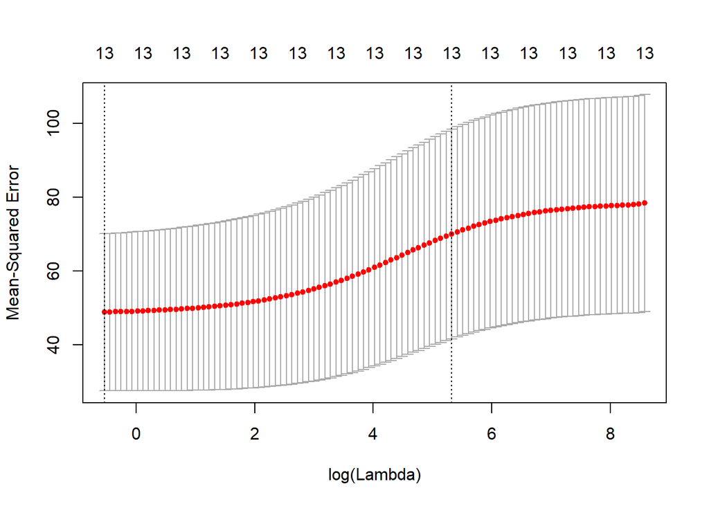

```r
set.seed(99)
train <- createDataPartition(y = Boston$crim, p=0.8,list = F)
Boston_train <- Boston[train,]
Boston_test <- Boston[-train,]
train_xmat <- model.matrix(crim~., data = Boston_train)[,-1]
test_xmat <- model.matrix(crim~., data = Boston_test)[,-1]

ridge.fit <- cv.glmnet(train_xmat, Boston_train$crim, alpha=0)
best_lambda_ridge = ridge.fit$lambda.min
ridge.pred <- predict(ridge.fit, s=best_lambda_ridge, newx = test_xmat)
plot(ridge.fit)
```

```r
ridge.mse <- (mean((Boston_test$crim - ridge.pred)^2))
best_lambda_ridge
```

```
## [1] 0.5855451
```

```r
ridge.mse
```

```
## [1] 23.66762
```

The best lambda for ridge regression is 0.5855451.  
Test MSE is 23.66762.

#### Lasso Regression

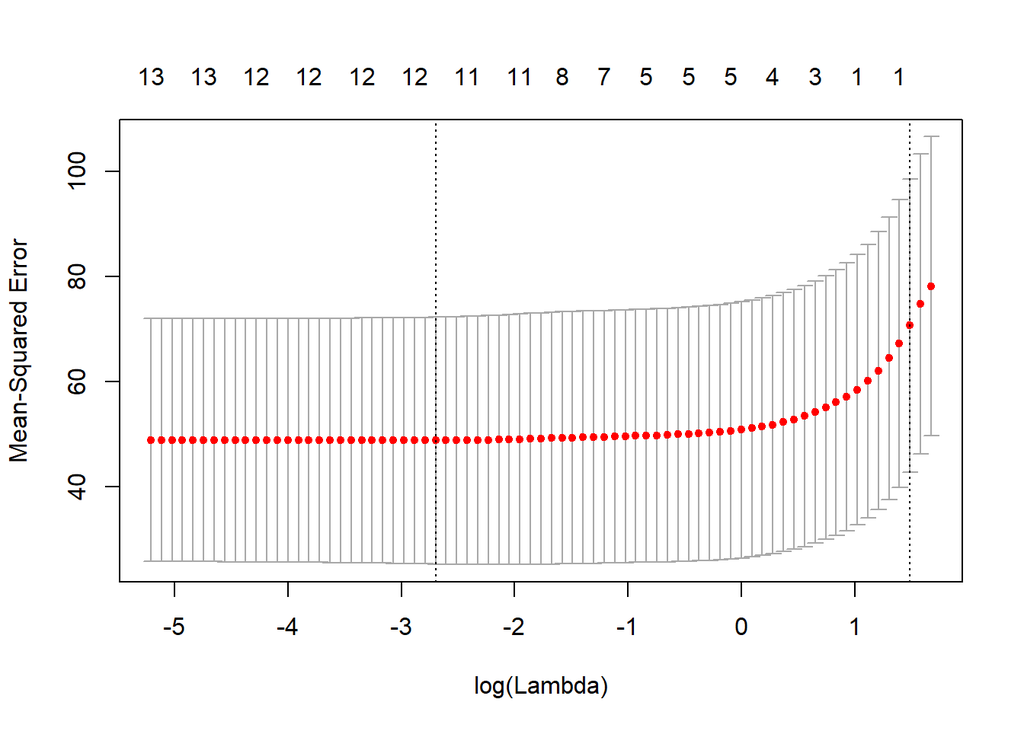

```r
set.seed(99)

lasso.fit <- cv.glmnet(train_xmat, Boston_train$crim, alpha=1)
best_lambda_lasso = lasso.fit$lambda.min
lasso.pred <- predict(lasso.fit, s=best_lambda_lasso, newx = test_xmat)
plot(lasso.fit)
```

```r
lasso.mse <- (mean((Boston_test$crim - lasso.pred)^2))
best_lambda_lasso
```

```
## [1] 0.06732346
```

```r
lasso.mse
```

```
## [1] 23.94604
```

The best lambda for lasso regression is 0.06732346.  
Test MSE is 23.94604.

#### PCR

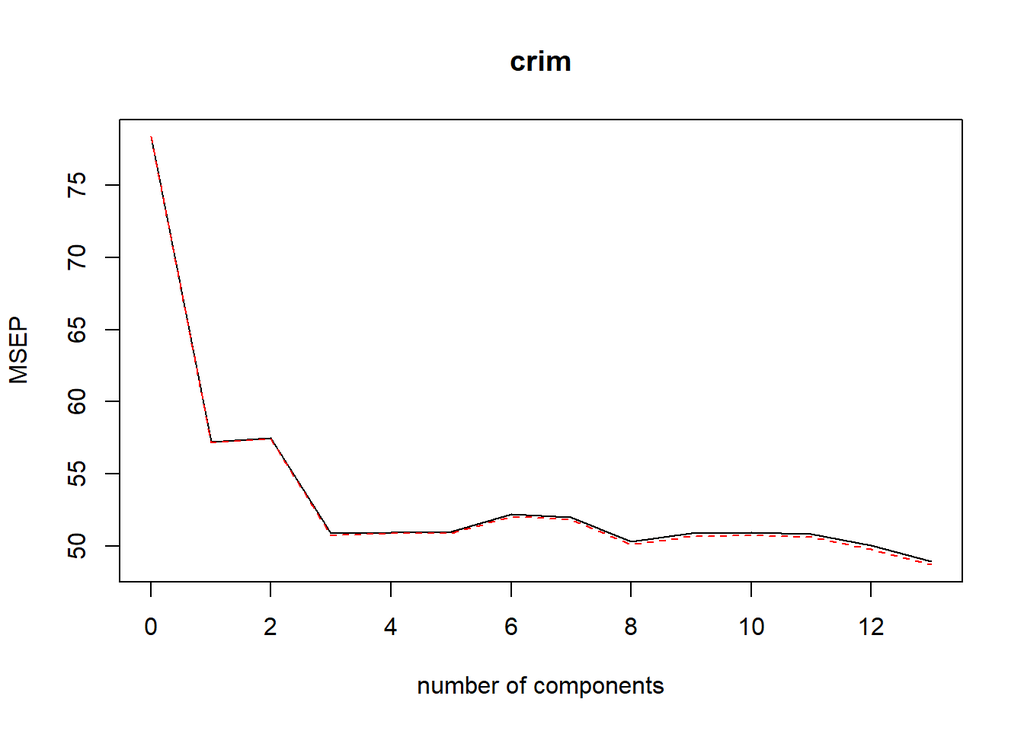

```r
set.seed(99)

pcr.fit = pcr(crim~., data = Boston_train, scale=T, validation = "CV")
pcr.pred <- predict(pcr.fit, Boston_test,ncomp = pcr.fit$ncomp)
validationplot(pcr.fit, val.type="MSEP")
```

```r
pcr.mse = mean((Boston_test$crim - pcr.pred)^2)
pcr.mse
```

```
## [1] 24.67265
```

```r
pcr.fit$ncomp
```

```
## [1] 13
```

PCR’s test MSE is 24.67265.  
M is 13.

### (b)

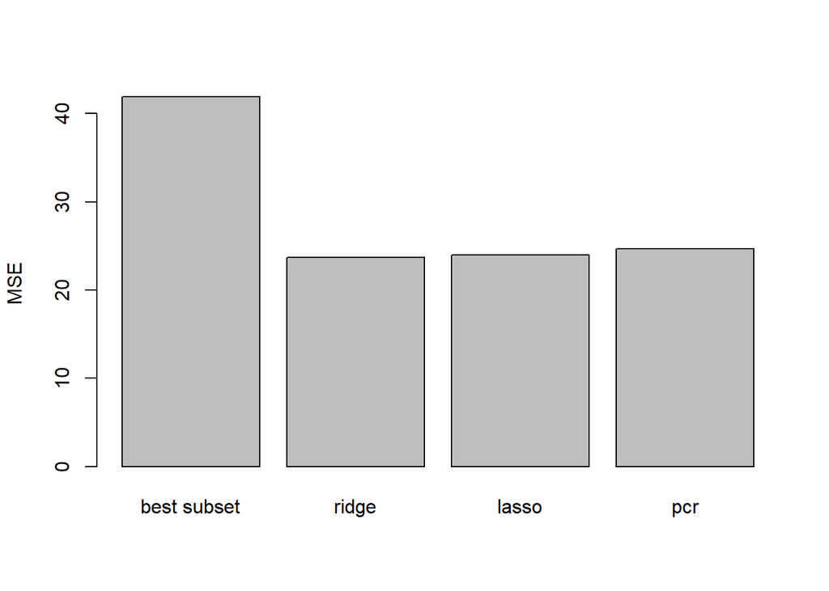

```r
all.mse = c(best.mse,ridge.mse,lasso.mse,pcr.mse)
names(all.mse) = c("best subset","ridge","lasso","pcr")
barplot(all.mse,ylab="MSE")
```

Ridge regression has the smallest test MSE.

### (c)

The model I choose is ridge regression model, because it has the smallest test MSE. Unlike best subset and lasso, ridge regression involves all of the features. However, the codfficeints maybe really close to zero.